# Section 2B: Confidence Interval Coverage

Shikhar Singh

2/4/2018

Lets compare the coverage of two confidence intervals - one made using Normal approximation (`equation 3.6` or HC2 robust standard errors), the other under the constant treatment effects assumption.

# Create Dataset

```r
library(dplyr)
library(randomizr)
library(knitr)

set.seed(100)

data <- data_frame(Y0 = rnorm(500, mean = 0, sd = 8), Y1 = Y0 + rnorm(500, mean = 5,
    sd = 4), X1 = as.numeric(Y0 >= 0), X2 = randomizr::complete_ra(N = 500,
    m = 250), C1 = ifelse(Y0 <= -1, 1, ifelse((Y0 > -1) & (Y0 <= 0), 2, ifelse((Y0 >
    0) & (Y0 <= 1), 3, 4))), C2 = sample(x = c(1, 2, 3, 4), size = 500, replace = T,
    prob = c(0.25, 0.25, 0.25, 0.25)))

kable(head(data), caption = "Dataset for Confidence Interval Converage Test",
    row.names = T)
```

Dataset for Confidence Interval Converage Test

|  | Y0 | Y1 | X1 | X2 | C1 | C2 |
| --- | --- | --- | --- | --- | --- | --- |
| 1 | -4.0175388 | -4.802689 | 0 | 1 | 1 | 2 |
| 2 | 1.0522493 | 7.315672 | 1 | 1 | 4 | 1 |
| 3 | -0.6313367 | 2.997673 | 0 | 1 | 2 | 1 |
| 4 | 7.0942785 | 4.368866 | 1 | 0 | 4 | 2 |
| 5 | 0.9357702 | 6.907054 | 1 | 1 | 3 | 4 |
| 6 | 2.5490407 | 6.097969 | 1 | 1 | 4 | 4 |

```r
true_ate <- mean(data$Y1 - data$Y0)  # True ATE
true_ate
```

```
## [1] 5.28487
```

# Sampling distribution of ATE estimates

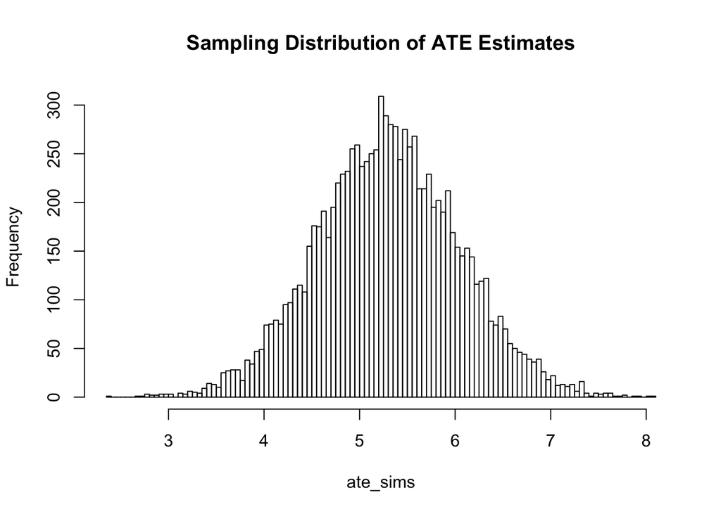

```r
declaration <- declare_ra(N = nrow(data), m = 250)  # Complete random assignment, m=250, N=500

Z <- conduct_ra(declaration)

# Get the sampling distribution of all ATE estimates

D <- obtain_permutation_matrix(declaration)

ate_sims <- rep(NA, ncol(D))

for (i in 1:ncol(D)) {
    Z_temp <- D[, i]
    Y <- data$Y1 * Z_temp + data$Y0 * (1 - Z_temp)
    ate_sims[i] <- mean(Y[Z_temp == 1]) - mean(Y[Z_temp == 0])
}

hist(ate_sims, breaks = 100, main = "Sampling Distribution of ATE Estimates")
```

# Performance of Normal approximation confidence intervals

To get the coverage of confidence intervals constructed using equation 3.6 I run a simulation in which for different samples of the population ($N_{pop}=500$ and $n_{sample}=200$), I compute the ate estimate, standard error estimate, and check if the resulting confidence interval contains the true ATE (which is known from the above dataset: $E[\tau_i] = 5.28487$).

```r
library(commarobust)

# Define output vector
coverage_normal <- rep(NA, 1000)
# For a random sample, create a declaration in randomizr
sample_declaration <- declare_rs(N = 500, n = 200)

for (i in 1:1000) {
    # Generate a random sample
    data$selected <- draw_rs(sample_declaration)
    sample <- data %>% filter(selected == 1)
    # Conduct complete random assignment
    Z_temp <- complete_ra(N = 200, m = 100)
    # Switching equation
    Y <- sample$Y1 * Z_temp + sample$Y0 * (1 - Z_temp)
    model <- lm(Y ~ Z_temp)
    # ATE estimate
    ate_estimate <- commarobust(model)[2, 1]
    # SE estimate (HC2 robust SE)
    se_estimate <- commarobust(model)[2, 2]
    # Construct CI
    ci_lower <- ate_estimate - 1.96 * se_estimate
    ci_upper <- ate_estimate + 1.96 * se_estimate
    # Check if this CI contains true ate
    coverage_normal[i] <- as.numeric((true_ate >= ci_lower) & (true_ate <= ci_upper))
}

# Coverage of CI
mean(coverage_normal)
```

```
## [1] 0.951
```

# Performance of Gerber and Green SEs

To get the coverage of confidence intervals constructed under the constant treatment effects assumption, I run a simulation in which for different samples ($n_{sample} = 200$) of the population ($N_{pop} = 500$), I compute the ate estimate, use that to get a hypothetical schedule of potential outcomes under the fixed effects assumption, and check if the resulting confidence interval contains the true ATE (5.28487)

```r
coverage_gerbgreen <- rep(NA, 1000)

sample_declaration <- declare_rs(N = 500, n = 200)

set.seed(32)

for (i in 1:1000) {
    # Generate a random sample
    data$selected <- draw_rs(sample_declaration)
    sample <- data %>% filter(selected == 1)
    # Conduct complete random assignment
    Z_temp <- complete_ra(N = 200, m = 100)
    # Switching equation
    Y <- sample$Y1 * Z_temp + sample$Y0 * (1 - Z_temp)
    model <- lm(Y ~ Z_temp)
    # ATE estimate
    ate_estimate <- commarobust(model)[2, 1]
    # SE estimate (under constant effects) Schedule of potential outcomes, under
    # fixed effects
    Y0_temp <- Y - ate_estimate * Z_temp
    Y1_temp <- Y0_temp + ate_estimate
    # Create permutation matrix
    declaration <- declare_ra(N = length(Y), m = length(Y)/2)
    D <- obtain_permutation_matrix(declaration, maximum_permutations = 1000)
    # Loop to get sampling distribution
    ate_sims <- rep(NA, ncol(D))
    for (j in 1:ncol(D)) {
        z_sim <- D[, j]
        # Compute ATE
        ate_sims[j] <- mean(Y1_temp[z_sim == 1]) - mean(Y0_temp[z_sim == 0])
    }
    # Construct CI
    ci_lower <- quantile(ate_sims, probs = 0.025)
    ci_upper <- quantile(ate_sims, probs = 0.975)
    # Check if this CI contains true ate
    coverage_gerbgreen[i] <- as.numeric((true_ate >= ci_lower) & (true_ate <=
        ci_upper))
}

# Coverage of CI
mean(coverage_gerbgreen)
```

```
## [1] 0.956
```

# Small and large sample properties

I write a function that computes coverage for different sample sizes: $n_{sample} \in \{10,50,100,250\}$.

| Sample.Size | Coverage.NormalApprox | Coverage.GerberGreen |
| --- | --- | --- |
| 10 | 0.912 | 0.896 |
| 50 | 0.944 | 0.932 |
| 100 | 0.961 | 0.951 |
| 250 | 0.949 | 0.947 |